# inspect_embeddings

### Part 6: Inspecting and Comparing Embeddings

```python
# Import packages
import nltk
nltk.download('punkt')

from nltk.tokenize import word_tokenize

def tokenize_text(text):
    return word_tokenize(text.lower())

import os
import pickle
import numpy as np
import umap
import matplotlib.pyplot as plt

from sklearn.metrics.pairwise import cosine_similarity
from sklearn.manifold import TSNE

import gensim
```

```python
with open('word2vec_embeddings.pkl', 'rb') as f:
    pt = pickle.load(f)
pt_embedding = np.array(pt['embeddings'])
pt_word2idx = pt['word2idx']
pt_idx2word = pt["idx2word"]

def get_vec_pytorch(word):
    i = pt_word2idx.get(word)
    return None if i is None else pt_embedding[i]
```

```python
print(pt_embedding.shape)
print("cat" in pt_word2idx)
print(get_vec_pytorch("cat")[:5])
```

```
(253854, 100)
True
[-0.66686577 -0.7373467   0.9716109  -0.53137404  0.69123685]
```

```python
with open('word2vec_gensim_embeddings.pkl', 'rb') as f:
    gs = pickle.load(f)

print(type(gs))
print(gs.keys() if hasattr(gs, 'keys') else 'no keys')
```

```
<class 'dict'>
dict_keys(['embeddings', 'word2idx', 'idx2word'])
```

```python
gs_embeddings = np.array(gs["embeddings"])
gs_word2idx = gs["word2idx"]

def get_vec_gensim_trained(word):
    i = gs_word2idx.get(word)
    return None if i is None else gs_embeddings[i]

def get_vec_google(word):
    try:
        return wvec_google[word]
    except keyError:
        return None

def get_vec_fasttext(word):
    try:
        return wvec_fasttext[word]
    except KeyError:
        return None
```

```python
# Loading pre-trained models to save locally
wvec_google = gensim.models.KeyedVectors.load('word2vec-google-news-300.model')
wvec_fasttext = gensim.models.KeyedVectors.load("fasttext-wiki-news-subwords-300.model")

# t-sne
print('google dim:', wvec_google.vector_size)
print('fast text dim:', wvec_fasttext.vector_size)
print('google has cat:', 'cat' in wvec_google)
print('fasttext has cat:', 'cat' in wvec_fasttext)
```

```
google dim: 300
fast text dim: 300
google has cat: True
fasttext has cat: True
```

```python
# List of sentences for comparison
sentences = [
    "The cat sat on the mat.",
    "A dog is playing in the yard.",
    "I need to buy groceries today.",
    "The feline was resting on the rug.",
    "Canines enjoy outdoor activities.",
    "My shopping list includes milk and bread.",
    "The weather is beautiful today.",
    "Programming requires logical thinking."
]

# Query sentence
query = "My pet cat is sleeping on the carpet."
query = "My pet cat is sleeping on the carpet."

# Nouns / words to be plotted
animals = [
    'dog', 'cat', 'horse', 'cow',
    'lion', 'tiger', 'elephant', 'giraffe',
    'eagle', 'hawk', 'sparrow', 'penguin',
    'shark', 'whale', 'dolphin', 'tuna'
]

foods = [
    'apple', 'orange', 'banana', 'grape',
    'bread', 'pasta', 'rice', 'potato',
    'chicken', 'beef', 'pork', 'fish',
    'coffee', 'tea', 'juice', 'water'
]
```

```python
# Creating plot format
def tsne_plot(name, get_vec_fn):
    X, labels, words = collect_vectors(get_vec_fn)

    tsne = TSNE(n_components=2, random_state = 0, perplexity =10)
    Y = tsne.fit_transform(X)

    plt.figure(figsize=(7, 7))
    for lbl in ['animal', 'food']:
        idx = [i for i, l in enumerate(labels) if l == lbl]
        plt.scatter(Y[idx,0], Y[idx,1], label=lbl)

    for i, w in enumerate(words):
        plt.text(Y[i,0], Y[i,1], w, fontsize = 9)

    plt.title(f"t-SNE: {name}")
    plt.legend()
    plt.show()
```

```python
def collect_vectors(get_vec_fn):
    words = animals + foods
    X = []
    labels = []
    kept_words = []

    for w in words:
        v = get_vec_fn(w)
        if v is not None:
            X.append(v)
            kept_words.append(w)
            labels.append("animal" if w in animals else "food")

    return np.array(X), labels, kept_words
```

[figure not shown]

[figure not shown]

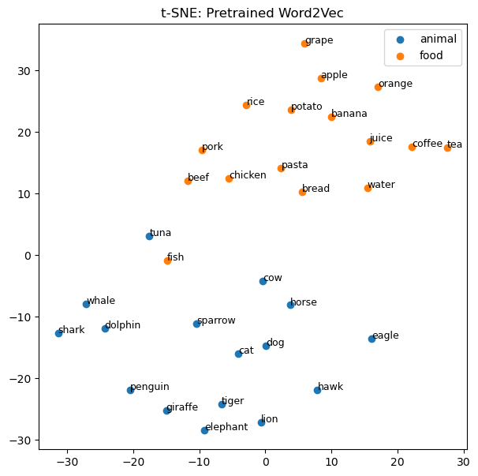

[figure not shown]

```python
tsne_plot("PyTorch (trained)", get_vec_pytorch)
tsne_plot("Gensim (trained)", get_vec_gensim_trained)
tsne_plot("Pretrained Word2Vec", get_vec_google)
tsne_plot("Pretrained FastText", get_vec_fasttext)
```

### UMAP plots

```python
def get_vec_gensim_trained(word):
    i = gs_word2idx.get(word)
    return None if i is None else gs_embeddings[i]

def get_vec_google(word):
    try:
        return wvec_google[word]
    except keyError:
        return None

def get_vec_fasttext(word):
    try:
        return wvec_fasttext[word]
    except KeyError:
        return None
```

```python
# Create umap object
def umap_plot(title, get_vec_fn):
    words = foods + animals
    kept_words = []
    vectors = []
    colors = []
    for w in words:
        v = get_vec_fn(w)
        if v is not None:
            kept_words.append(w)
            vectors.append(v)
            if w in foods:
                colors.append('orange')
            else:
                colors.append('blue')
    vectors = np.array(vectors, dtype = np.float32)
    reducer = umap.UMAP(n_neighbors = 10,
    min_dist = 0.1,
    n_components = 2,
    random_state = 42)
    reduced = reducer.fit_transform(vectors)
    plt.figure(figsize = (8, 6))
    for i, w in enumerate(kept_words):
        plt.scatter(reduced[i, 0], reduced[i, 1], c=colors[i])
        plt.annotate(w, (reduced[i, 0], reduced[i, 1]))

    plt.title(title)
    plt.xlabel('UMAP 1')
    plt.ylabel('UMAP 2')
    plt.show()
```

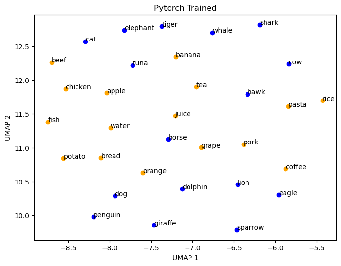

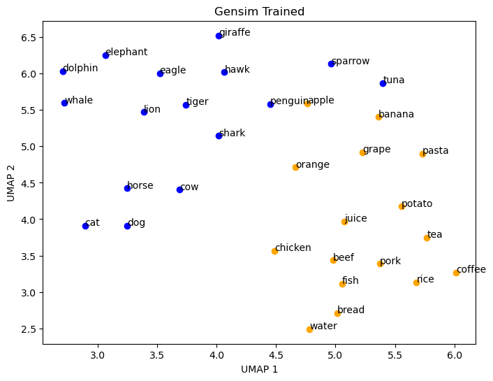

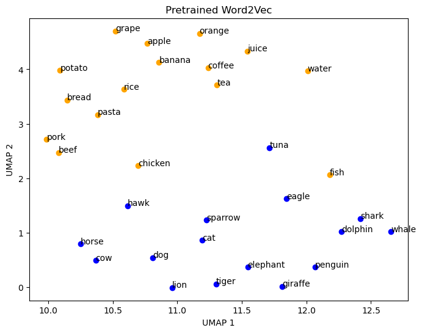

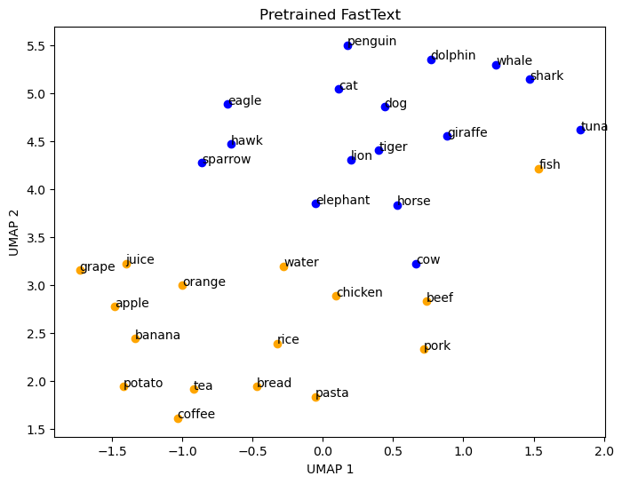

```python
umap_plot('Pytorch Trained', get_vec_pytorch)
umap_plot('Gensim Trained', get_vec_gensim_trained)
umap_plot('Pretrained Word2Vec', get_vec_google)
umap_plot("Pretrained FastText", get_vec_fasttext)
```

## AI Use Disclosure (Required)

If you used any AI-enabled tools (e.g., ChatGPT, GitHub Copilot, Claude, or other LLM assistants) while working on this assignment, you must disclose that use here. The goal is transparency-not punishment.

In your disclosure, briefly include:

- **Tool(s) used:** (name + version if known)
- **How you used them:** (e.g., concept explanation, debugging, drafting code, rewriting text)
- **What you verified yourself:** (e.g., reran the notebook, checked outputs/plots, checked shapes, read documentation)
- **What you did *not* use AI for (if applicable):** (optional)

You are responsible for the correctness of your submission, even if AI suggested code or explanations.

#### I used AI tools ChatGPT and Google’s Notebook LM to simplify lecture slide content and proofread structure and flow of my writing. I refered to course materials / AI-generated summaries to edit and correct my responses. I independently re-ran code cells, inspected outpits and confirm the validity of output to course content. I also used ChatGPT to debug code and iterate the code myself using its responses..